# HW3 – Ying Zheng

Part I - Problem 1

```r
data(IncomeUK)
consumption = IncomeUK[,2]
plot(consumption)
```

[figure not shown]

We are able to remove the trend by taking first order difference but it still seems not stationary (variance getting larger as time getting larger). So we try to take difference of log consumption.

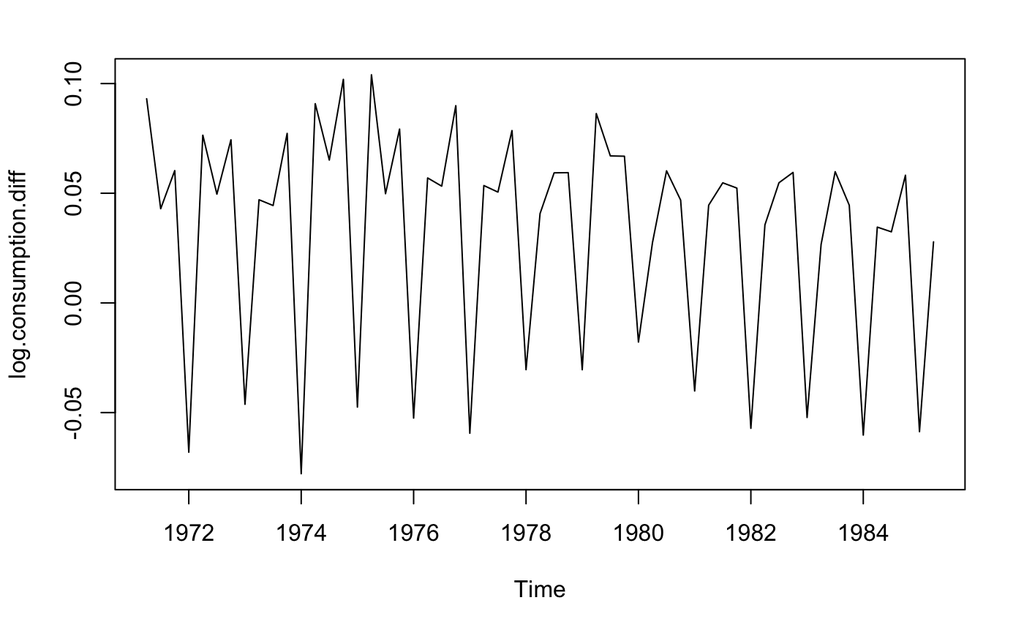

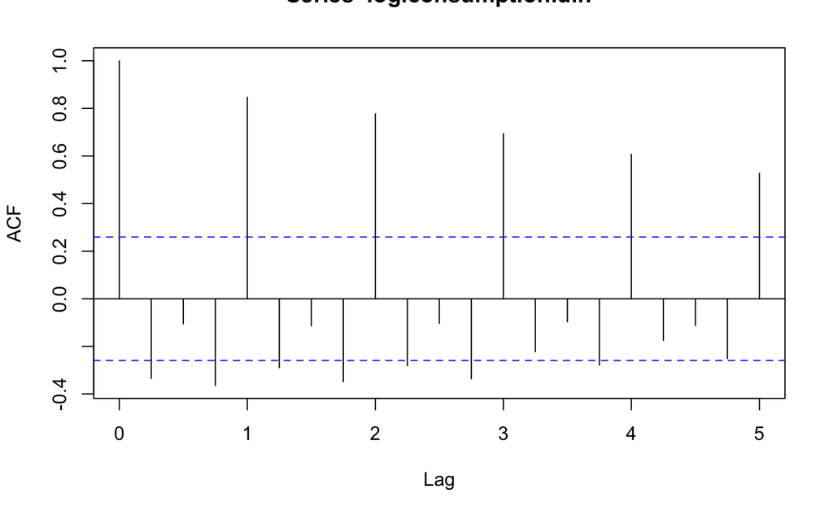

Both the row data and ACF consumption differencing suggest a clear seasonal pattern. So we should do seasonal differening. Also, it’s easy to see that log transformation gives a more stationary time series. So we should fit seasonal ARIMA model to the data with a log transformation.

Problem 2

```r
log.consumption = ts(log(consumption), frequency = 4)
holdfit.logC = auto.arima(log.consumption, approx = F, stepwise = F)
holdfit.logC
```

```
Series: log.consumption
ARIMA(0,1,0)(0,1,1)[4]

Coefficients:
         sma1
      -0.5348
s.e.   0.1164

sigma^2 estimated as 0.0003056:  log likelihood=139.77
AIC=-275.55   AICc=-275.31   BIC=-271.61
```

By looking at the result, we can tell that: for the non-seasonal part, the order of autoregression is 0, the degree of differencing is 1 and the order of moving average is 0; for the seasonal part (with period of 4), the order of autoregression is 0, the degree of differencing is 1 and the order of moving average is 1.

Problem 3

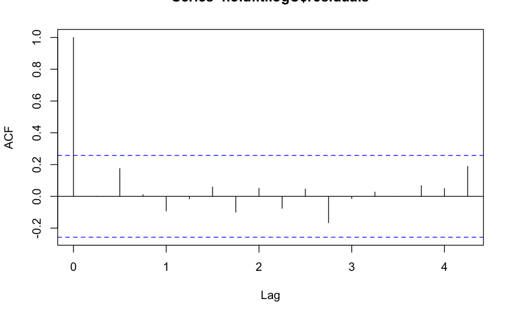

There is no significant statistical evidence to reject that the residuals have no correlations.

Part II

```r
library(quantmod)
```

1. The plot does not seem stationary.

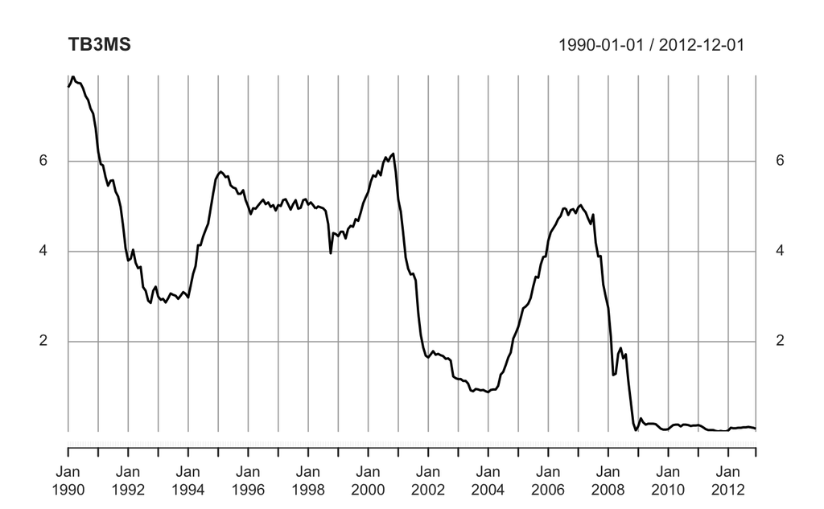

```r
adf.test(as.numeric(TB3MS.diff[-1]), alternative = "s")
```

```
    Augmented Dickey-Fuller Test

data:  as.numeric(TB3MS.diff[-1])
Dickey-Fuller = -3.5576, Lag order = 6, p-value = 0.03763
alternative hypothesis: stationary
```

By looking at first order difference on both row and transformed data, it seems that the not transformed one is more stationary. We did ADF test on that and got a p value of 0.03763, which is less than 0.05. So we accept the alternative hypothesis that the difference on row data is stationary.

```r
holdfit.TB3MS = auto.arima(TB3MS, approximation = F, stepwise = F)
holdfit.TB3MS
```

```
Series: TB3MS
ARIMA(3,1,0)

Coefficients:
         ar1      ar2     ar3
      0.4093  -0.0300  0.2523
s.e.  0.0582   0.0633  0.0582

sigma^2 estimated as 0.02894:  log likelihood=98.17
AIC=-188.34   AICc=-188.19   BIC=-173.87
```

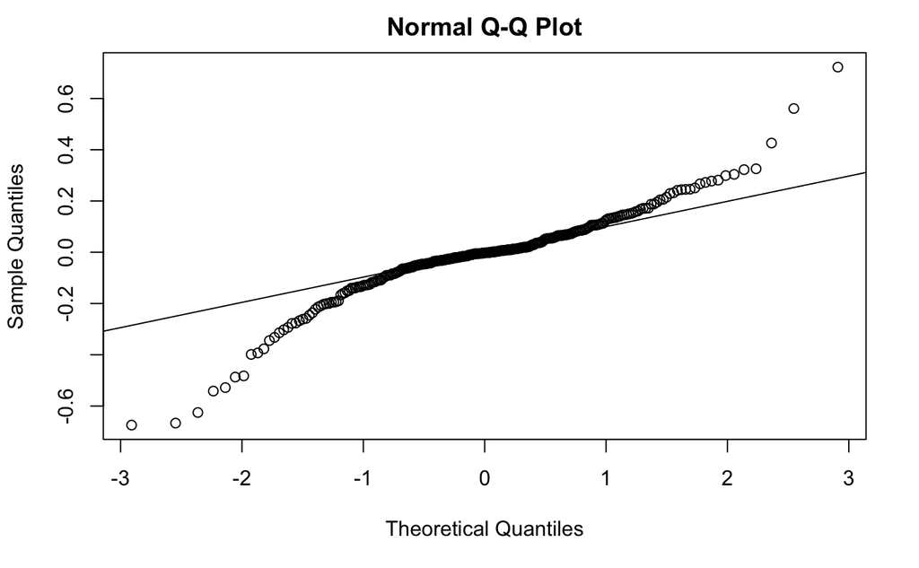

```r
holdpreds = predict(holdfit.TB3MS, n.ahead = 3)
CI.1 = c(holdpreds$pred[1]-1.96*holdpreds$se[1],holdpreds$pred[1]+1.96*holdpreds$se[1])
CI.2 = c(holdpreds$pred[2]-1.96*holdpreds$se[2],holdpreds$pred[2]+1.96*holdpreds$se[2])
CI.3 = c(holdpreds$pred[3]-1.96*holdpreds$se[3],holdpreds$pred[3]+1.96*holdpreds$se[3])
CI.1
```

```
[1] -0.2738443  0.3930244
```

```r
CI.2
```

```
[1] -0.5227881  0.6295988
```

```r
CI.3
```

```
[1] -0.7271855  0.8194638
```

6. Yes, the three intervals include the observed values.

```r
TB3MS.all["2013"][1:3]
```

```
           TB3MS
2013-01-01  0.07
2013-02-01  0.10
2013-03-01  0.09
```